# EST_project

1. Data Understanding & Exploration: [5 Marks] A. Read ‘TelcomCustomer-Churn_1.csv’ as a DataFrame and assign it to a variable. [1 Mark] B. Read ‘TelcomCustomer-Churn_2.csv’ as a DataFrame and assign it to a variable. [1 Mark] C. Merge both the DataFrames on key ‘customerID’ to form a single DataFrame [2 Mark] D. Verify if all the columns are incorporated in the merged DataFrame by using simple comparison Operator in Python. [1 Marks]

```python
# To enable plotting graphs in Jupyter notebook
%matplotlib inline
import numpy as np
import pandas as pd
from sklearn.model_selection import train_test_split
from sklearn.neighbors import KNeighborsClassifier
from scipy.stats import zscore
from sklearn.metrics import classification_report
from sklearn.metrics import roc_auc_score
from sklearn.model_selection import GridSearchCV
import seaborn as sns
import matplotlib.pyplot as plt
```

```python
t1 = pd.read_csv("TelcomCustomer-Churn_1.csv")
```

```python
t2 = pd.read_csv("TelcomCustomer-Churn_2.csv")
```

```python
t = [t1, t2]

for df in t:
    print(df.shape)
```

```
(7043, 10)
(7043, 12)
```

```python
t = [t1, t2]

for df in t:
    print(df.dtypes)
```

```
customerID         object
gender             object
SeniorCitizen       int64
Partner            object
Dependents         object
tenure              int64
PhoneService       object
MultipleLines      object
InternetService    object
OnlineSecurity     object
dtype: object
customerID           object
OnlineBackup         object
DeviceProtection     object
TechSupport          object
StreamingTV          object
StreamingMovies      object
Contract             object
PaperlessBilling     object
PaymentMethod        object
MonthlyCharges      float64
TotalCharges         object
Churn                object
dtype: object
```

```python
np.all([sorted(t[0].columns) == sorted(i.columns) for i in t]) # in both the datasets attributes name are different
```

```
False
```

```python
t_merg= t1.merge(t2, on='customerID') #Merge both the DataFrames on key ‘customerID’ to form a single DataFrame
t_merg
```

|  | customerID | gender | SeniorCitizen | Partner | Dependents | tenure | PhoneService | MultipleLines | InternetService | OnlineSecurity | ... | DeviceProtection | TechSupport | StreamingTV | StreamingMovies | Contract | PaperlessBilling | PaymentMethod | MonthlyCharges | TotalCharges | Churn |
| --- | --- | --- | --- | --- | --- | --- | --- | --- | --- | --- | --- | --- | --- | --- | --- | --- | --- | --- | --- | --- | --- |
| 0 | 7590-VHVEG | Female | 0 | Yes | No | 1 | No | No phone service | DSL | No | ... | No | No | No | No | Month-to-month | Yes | Electronic check | 29.85 | 29.85 | No |
| 1 | 5575-GNVDE | Male | 0 | No | No | 34 | Yes | No | DSL | Yes | ... | Yes | No | No | No | One year | No | Mailed check | 56.95 | 1889.5 | No |
| 2 | 3668-QPYBK | Male | 0 | No | No | 2 | Yes | No | DSL | Yes | ... | No | No | No | No | Month-to-month | Yes | Mailed check | 53.85 | 108.15 | Yes |
| 3 | 7795-CFOCW | Male | 0 | No | No | 45 | No | No phone service | DSL | Yes | ... | Yes | Yes | No | No | One year | No | Bank transfer (automatic) | 42.30 | 1840.75 | No |
| 4 | 9237-HQITU | Female | 0 | No | No | 2 | Yes | No | Fiber optic | No | ... | No | No | No | No | Month-to-month | Yes | Electronic check | 70.70 | 151.65 | Yes |
| ... | ... | ... | ... | ... | ... | ... | ... | ... | ... | ... | ... | ... | ... | ... | ... | ... | ... | ... | ... | ... | ... |
| 7038 | 6840-RESVB | Male | 0 | Yes | Yes | 24 | Yes | Yes | DSL | Yes | ... | Yes | Yes | Yes | Yes | One year | Yes | Mailed check | 84.80 | 1990.5 | No |
| 7039 | 2234-XADUH | Female | 0 | Yes | Yes | 72 | Yes | Yes | Fiber optic | No | ... | Yes | No | Yes | Yes | One year | Yes | Credit card (automatic) | 103.20 | 7362.9 | No |
| 7040 | 4801-JZAZL | Female | 0 | Yes | Yes | 11 | No | No phone service | DSL | Yes | ... | No | No | No | No | Month-to-month | Yes | Electronic check | 29.60 | 346.45 | No |
| 7041 | 8361-LTMKD | Male | 1 | Yes | No | 4 | Yes | Yes | Fiber optic | No | ... | No | No | No | No | Month-to-month | Yes | Mailed check | 74.40 | 306.6 | Yes |
| 7042 | 3186-AJIEK | Male | 0 | No | No | 66 | Yes | No | Fiber optic | Yes | ... | Yes | Yes | Yes | Yes | Two year | Yes | Bank transfer (automatic) | 105.65 | 6844.5 | No |

7043 rows × 21 columns

```python
t_merg.info()
```

```
<class 'pandas.core.frame.DataFrame'>
Int64Index: 7043 entries, 0 to 7042
Data columns (total 21 columns):
 #   Column            Non-Null Count  Dtype
---  ------            --------------  -----
 0   customerID        7043 non-null   object
 1   gender            7043 non-null   object
 2   SeniorCitizen     7043 non-null   int64
 3   Partner           7043 non-null   object
 4   Dependents        7043 non-null   object
 5   tenure            7043 non-null   int64
 6   PhoneService      7043 non-null   object
 7   MultipleLines     7043 non-null   object
 8   InternetService   7043 non-null   object
 9   OnlineSecurity    7043 non-null   object
 10  OnlineBackup      7043 non-null   object
 11  DeviceProtection  7043 non-null   object
 12  TechSupport       7043 non-null   object
 13  StreamingTV       7043 non-null   object
 14  StreamingMovies   7043 non-null   object
 15  Contract          7043 non-null   object
 16  PaperlessBilling  7043 non-null   object
 17  PaymentMethod     7043 non-null   object
 18  MonthlyCharges    7043 non-null   float64
 19  TotalCharges      7043 non-null   object
 20  Churn             7043 non-null   object
dtypes: float64(1), int64(2), object(18)
memory usage: 1.2+ MB
```

```python
print(t_merg[t_merg.isna().any(axis=1)]) # Verify if all the columns are incorporated in the merged DataFrame by using simple comparison Operator in Python.
```

```
Empty DataFrame
Columns: [customerID, gender, SeniorCitizen, Partner, Dependents, tenure, PhoneService, MultipleLines, InternetService, OnlineSecurity, OnlineBackup, DeviceProtection, TechSupport, StreamingTV, StreamingMovies, Contract, PaperlessBilling, PaymentMethod, MonthlyCharges, TotalCharges, Churn]
Index: []

[0 rows x 21 columns]
```

all the columns are present in the merged dataframe2. Data Cleaning & Analysis: [15 Marks] A. Impute missing/unexpected values in the DataFrame. [2 Marks] B. Make sure all the variables with continuous values are of ‘Float’ type. [2 Marks] [For Example: MonthlyCharges, TotalCharges] C. Create a function that will accept a DataFrame as input and return pie-charts for all the appropriate Categorical features. Clearly show percentage distribution in the pie-chart. [4 Marks] D. Share insights for Q2.c. [2 Marks] E. Encode all the appropriate Categorical features with the best suitable approach. [2 Marks] F. Split the data into 80% train and 20% test. [1 Marks] G. Normalize/Standardize the data with the best suitable approach. [2 Marks]

```python
percent_missing= t_merg.isnull().sum()*100/len(t_merg) # check for the missing value in dataframe
print(percent_missing)
```

```
customerID          0.0
gender              0.0
SeniorCitizen       0.0
Partner             0.0
Dependents          0.0
tenure              0.0
PhoneService        0.0
MultipleLines       0.0
InternetService     0.0
OnlineSecurity      0.0
OnlineBackup        0.0
DeviceProtection    0.0
TechSupport         0.0
StreamingTV         0.0
StreamingMovies     0.0
Contract            0.0
PaperlessBilling    0.0
PaymentMethod       0.0
MonthlyCharges      0.0
TotalCharges        0.0
Churn               0.0
dtype: float64
```

no missing value was found in dataframe

```python
for cols in t_merg.columns:
  print(cols)
  print(t_merg[cols].unique())
  print("\n")
```

```
customerID
['7590-VHVEG' '5575-GNVDE' '3668-QPYBK' ... '4801-JZAZL' '8361-LTMKD'
 '3186-AJIEK']


gender
['Female' 'Male']


SeniorCitizen
[0 1]


Partner
['Yes' 'No']


Dependents
['No' 'Yes']


tenure
[ 1 34  2 45  8 22 10 28 62 13 16 58 49 25 69 52 71 21 12 30 47 72 17 27
  5 46 11 70 63 43 15 60 18 66  9  3 31 50 64 56  7 42 35 48 29 65 38 68
 32 55 37 36 41  6  4 33 67 23 57 61 14 20 53 40 59 24 44 19 54 51 26  0
 39]


PhoneService
['No' 'Yes']


MultipleLines
['No phone service' 'No' 'Yes']


InternetService
['DSL' 'Fiber optic' 'No']


```

[output cut: 32 more lines]

```
PaymentMethod
['Electronic check' 'Mailed check' 'Bank transfer (automatic)'
 'Credit card (automatic)']


MonthlyCharges
[29.85 56.95 53.85 ... 63.1  44.2  78.7 ]


TotalCharges
['29.85' '1889.5' '108.15' ... '346.45' '306.6' '6844.5']


Churn
['No' 'Yes']
```

```python
t_merg = t_merg.astype({'SeniorCitizen': 'float', 'tenure': 'float', 'MonthlyCharges': 'float'}) # change all the continuous variable to flot type
t_merg.dtypes
```

```
customerID           object
gender               object
SeniorCitizen       float64
Partner              object
Dependents           object
tenure              float64
PhoneService         object
MultipleLines        object
InternetService      object
OnlineSecurity       object
OnlineBackup         object
DeviceProtection     object
TechSupport          object
StreamingTV          object
StreamingMovies      object
Contract             object
PaperlessBilling     object
PaymentMethod        object
MonthlyCharges      float64
TotalCharges         object
Churn                object
dtype: object
```

```python
no_missing= t_merg.isnull().sum() # check for the missing value in dataframe
print(no_missing)
```

```
customerID          0
gender              0
SeniorCitizen       0
Partner             0
Dependents          0
tenure              0
PhoneService        0
MultipleLines       0
InternetService     0
OnlineSecurity      0
OnlineBackup        0
DeviceProtection    0
TechSupport         0
StreamingTV         0
StreamingMovies     0
Contract            0
PaperlessBilling    0
PaymentMethod       0
MonthlyCharges      0
TotalCharges        0
Churn               0
dtype: int64
```

there are no missing values in total charges, so no need of replacememt

```python
medianFiller = lambda x: x.fillna(0)
t_merg = t_merg.apply(medianFiller,axis=0)
t_merg.head(5)
```

|  | customerID | gender | SeniorCitizen | Partner | Dependents | tenure | PhoneService | MultipleLines | InternetService | OnlineSecurity | ... | DeviceProtection | TechSupport | StreamingTV | StreamingMovies | Contract | PaperlessBilling | PaymentMethod | MonthlyCharges | TotalCharges | Churn |
| --- | --- | --- | --- | --- | --- | --- | --- | --- | --- | --- | --- | --- | --- | --- | --- | --- | --- | --- | --- | --- | --- |
| 0 | 7590-VHVEG | Female | 0.0 | Yes | No | 1.0 | No | No phone service | DSL | No | ... | No | No | No | No | Month-to-month | Yes | Electronic check | 29.85 | 29.85 | No |
| 1 | 5575-GNVDE | Male | 0.0 | No | No | 34.0 | Yes | No | DSL | Yes | ... | Yes | No | No | No | One year | No | Mailed check | 56.95 | 1889.5 | No |
| 2 | 3668-QPYBK | Male | 0.0 | No | No | 2.0 | Yes | No | DSL | Yes | ... | No | No | No | No | Month-to-month | Yes | Mailed check | 53.85 | 108.15 | Yes |
| 3 | 7795-CFOCW | Male | 0.0 | No | No | 45.0 | No | No phone service | DSL | Yes | ... | Yes | Yes | No | No | One year | No | Bank transfer (automatic) | 42.30 | 1840.75 | No |
| 4 | 9237-HQITU | Female | 0.0 | No | No | 2.0 | Yes | No | Fiber optic | No | ... | No | No | No | No | Month-to-month | Yes | Electronic check | 70.70 | 151.65 | Yes |

5 rows × 21 columns

```python
t_merg.isnull().sum() # check if all the missing values are replaced with the median
```

```
customerID          0
gender              0
SeniorCitizen       0
Partner             0
Dependents          0
tenure              0
PhoneService        0
MultipleLines       0
InternetService     0
OnlineSecurity      0
OnlineBackup        0
DeviceProtection    0
TechSupport         0
StreamingTV         0
StreamingMovies     0
Contract            0
PaperlessBilling    0
PaymentMethod       0
MonthlyCharges      0
TotalCharges        0
Churn               0
dtype: int64
```

```python
#Function to plot Pie-Charts for all categorical variables in the dataframe
def pie_charts_for_CategoricalVar(t_merg,m):
   # '''Takes in a dataframe(t_merg) and plots pie charts for all categorical columns. m = number of columns required in grid'''

    #get all the column names in the dataframe
    a = []
    for i in t_merg:
        a.append(i)

    #isolate the categorical variable names from a to b
    b = []
    for i in a:
        if (t_merg[i].dtype.name) == 'object':
            b.append(i)

    plt.figure(figsize=(15, 12))
    plt.subplots_adjust(hspace=0.2)
    plt.suptitle("Pie-Charts for Categorical Variables in the dataframe", fontsize=18, y=0.95)

    # number of columns, as inputted while calling the function
    ncols = m
    # calculate number of rows
    nrows = len(b) // ncols + (len(b) % ncols > 0)

    # loop through the length of 'b' and keep track of index
    for n, i in enumerate(b):
        # add a new subplot iteratively using nrows and ncols
        ax = plt.subplot(nrows, ncols, n + 1)

        # filter df and plot 'i' on the new subplot axis
        t_merg.groupby(i).size().plot(kind='pie', autopct='%.2f%%',ax=ax)

        ax.set_title(i.upper())
        ax.set_xlabel("")
        ax.set_ylabel("")
    plt.show()
```

[figure not shown]

```python
pie_charts_for_CategoricalVar(t_merg,5)
```

```python
t_merg.corr()
```

|  | SeniorCitizen | tenure | MonthlyCharges |
| --- | --- | --- | --- |
| SeniorCitizen | 1.000000 | 0.016567 | 0.220173 |
| tenure | 0.016567 | 1.000000 | 0.247900 |
| MonthlyCharges | 0.220173 | 0.247900 | 1.000000 |

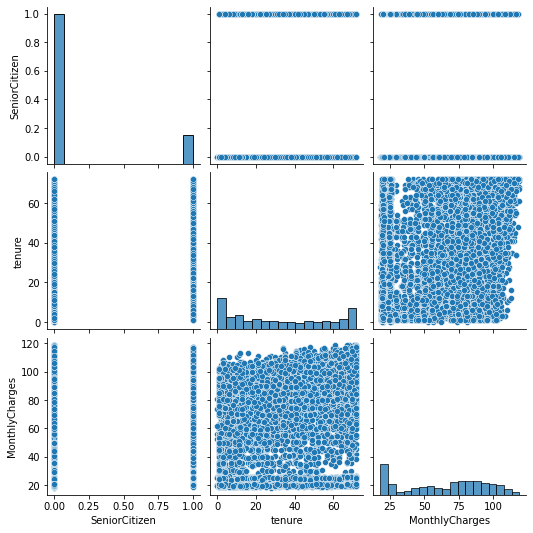

```python
sns.pairplot(t_merg)
```

```python
# encode all the features
from sklearn.preprocessing import LabelEncoder, OneHotEncoder
from sklearn.preprocessing import MinMaxScaler

cols = ['SeniorCitizen', 'Partner', 'Dependents', 'PaperlessBilling']

X = pd.get_dummies(t_merg, columns=cols, drop_first=True)
```

```python
encode_nums = {"MultipleLines": {"No phone service": 0, "No": 1, "Yes": 2},
                "InternetService":{"No": 0, "DSL": 1, "Fiber optic": 2},
                "OnlineSecurity" :{"No" : 0, "No internet service" : 1, "Yes": 2},
                "OnlineBackup" :{"No" : 0, "No internet service" : 1, "Yes": 2},
                "DeviceProtection" :{"No" : 0, "No internet service" : 1, "Yes": 2},
                "TechSupport" :{"No" : 0, "No internet service" : 1, "Yes": 2},
                "StreamingTV" :{"No" : 0, "No internet service" : 1, "Yes": 2},
                "StreamingMovies" :{"No" : 0, "No internet service" : 1, "Yes": 2},
                "PaymentMethod" : {'Electronic check': 1, 'Mailed check' : 2, 'Bank transfer (automatic)': 3,'Credit card (automatic)':4},
                "Contract" : {'Month-to-month' : 0, 'One year': 1, 'Two year':2},
                "Churn" :{"No" : 0, "Yes": 1},
               "gender" :{"Male" : 0, "Female": 1},
               "Partner" :{"No" : 0, "Yes": 1},
               "Dependents" :{"No" : 0, "Yes": 1},
               "PhoneService" :{"No" : 0, "Yes": 1},
               "PaperlessBilling" :{"No" : 0, "Yes": 1}}
t_merg = t_merg.replace(encode_nums)
t_merg.head()
```

|  | customerID | gender | SeniorCitizen | Partner | Dependents | tenure | PhoneService | MultipleLines | InternetService | OnlineSecurity | ... | DeviceProtection | TechSupport | StreamingTV | StreamingMovies | Contract | PaperlessBilling | PaymentMethod | MonthlyCharges | TotalCharges | Churn |
| --- | --- | --- | --- | --- | --- | --- | --- | --- | --- | --- | --- | --- | --- | --- | --- | --- | --- | --- | --- | --- | --- |
| 0 | 7590-VHVEG | 1 | 0.0 | 1 | 0 | 1.0 | 0 | 0 | 1 | 0 | ... | 0 | 0 | 0 | 0 | 0 | 1 | 1 | 29.85 | 29.85 | 0 |
| 1 | 5575-GNVDE | 0 | 0.0 | 0 | 0 | 34.0 | 1 | 1 | 1 | 2 | ... | 2 | 0 | 0 | 0 | 1 | 0 | 2 | 56.95 | 1889.5 | 0 |
| 2 | 3668-QPYBK | 0 | 0.0 | 0 | 0 | 2.0 | 1 | 1 | 1 | 2 | ... | 0 | 0 | 0 | 0 | 0 | 1 | 2 | 53.85 | 108.15 | 1 |
| 3 | 7795-CFOCW | 0 | 0.0 | 0 | 0 | 45.0 | 0 | 0 | 1 | 2 | ... | 2 | 2 | 0 | 0 | 1 | 0 | 3 | 42.30 | 1840.75 | 0 |
| 4 | 9237-HQITU | 1 | 0.0 | 0 | 0 | 2.0 | 1 | 1 | 2 | 0 | ... | 0 | 0 | 0 | 0 | 0 | 1 | 1 | 70.70 | 151.65 | 1 |

5 rows × 21 columns

```python
t_merg.info()
```

```
<class 'pandas.core.frame.DataFrame'>
Int64Index: 7043 entries, 0 to 7042
Data columns (total 21 columns):
 #   Column            Non-Null Count  Dtype
---  ------            --------------  -----
 0   customerID        7043 non-null   object
 1   gender            7043 non-null   int64
 2   SeniorCitizen     7043 non-null   float64
 3   Partner           7043 non-null   int64
 4   Dependents        7043 non-null   int64
 5   tenure            7043 non-null   float64
 6   PhoneService      7043 non-null   int64
 7   MultipleLines     7043 non-null   int64
 8   InternetService   7043 non-null   int64
 9   OnlineSecurity    7043 non-null   int64
 10  OnlineBackup      7043 non-null   int64
 11  DeviceProtection  7043 non-null   int64
 12  TechSupport       7043 non-null   int64
 13  StreamingTV       7043 non-null   int64
 14  StreamingMovies   7043 non-null   int64
 15  Contract          7043 non-null   int64
 16  PaperlessBilling  7043 non-null   int64
 17  PaymentMethod     7043 non-null   int64
 18  MonthlyCharges    7043 non-null   float64
 19  TotalCharges      7043 non-null   object
 20  Churn             7043 non-null   int64
dtypes: float64(3), int64(16), object(2)
memory usage: 1.2+ MB
```

```python
import scipy.stats as stats

for i in t_merg:
  crosstab=pd.crosstab(t_merg['Churn'],t_merg[i])
  chi_sq_Stat, p_value, deg_freedom, exp_freq = stats.chi2_contingency(crosstab)

  print('Chi-square statistic: %3.5f , P value:  %1.6f' %(chi_sq_Stat, p_value))

  if p_value < 0.05:  # Setting our significance level at 5%
        print('Rejecting Null Hypothesis: Customer who Churn and who do not Churn does NOT have same distribution of {}'.format(i))
        print('\n')
  else:
        print('Fail to Reject Null Hypothesis: Customer who Churn and who do not Churn have same distribution of {}'.format(i))
        print('\n')
```

```
Chi-square statistic: 7043.00000 , P value:  0.494398
Fail to Reject Null Hypothesis: Customer who Churn and who do not Churn have same distribution of customerID


Chi-square statistic: 0.48408 , P value:  0.486579
Fail to Reject Null Hypothesis: Customer who Churn and who do not Churn have same distribution of gender


Chi-square statistic: 159.42630 , P value:  0.000000
Rejecting Null Hypothesis: Customer who Churn and who do not Churn does NOT have same distribution of SeniorCitizen


Chi-square statistic: 158.73338 , P value:  0.000000
Rejecting Null Hypothesis: Customer who Churn and who do not Churn does NOT have same distribution of Partner


Chi-square statistic: 189.12925 , P value:  0.000000
Rejecting Null Hypothesis: Customer who Churn and who do not Churn does NOT have same distribution of Dependents


Chi-square statistic: 1065.33086 , P value:  0.000000
Rejecting Null Hypothesis: Customer who Churn and who do not Churn does NOT have same distribution of tenure


Chi-square statistic: 0.91503 , P value:  0.338783
Fail to Reject Null Hypothesis: Customer who Churn and who do not Churn have same distribution of PhoneService


Chi-square statistic: 11.33044 , P value:  0.003464
Rejecting Null Hypothesis: Customer who Churn and who do not Churn does NOT have same distribution of MultipleLines


Chi-square statistic: 732.30959 , P value:  0.000000
Rejecting Null Hypothesis: Customer who Churn and who do not Churn does NOT have same distribution of InternetService


Chi-square statistic: 849.99897 , P value:  0.000000
Rejecting Null Hypothesis: Customer who Churn and who do not Churn does NOT have same distribution of OnlineSecurity


```

[output cut: 27 more lines]

```

Chi-square statistic: 648.14233 , P value:  0.000000
Rejecting Null Hypothesis: Customer who Churn and who do not Churn does NOT have same distribution of PaymentMethod


Chi-square statistic: 2123.60913 , P value:  0.000000
Rejecting Null Hypothesis: Customer who Churn and who do not Churn does NOT have same distribution of MonthlyCharges


Chi-square statistic: 6514.04781 , P value:  0.553246
Fail to Reject Null Hypothesis: Customer who Churn and who do not Churn have same distribution of TotalCharges


Chi-square statistic: 7037.87138 , P value:  0.000000
Rejecting Null Hypothesis: Customer who Churn and who do not Churn does NOT have same distribution of Churn
```

```python
t_merg.corr()
```

|  | gender | SeniorCitizen | Partner | Dependents | tenure | PhoneService | MultipleLines | InternetService | OnlineSecurity | OnlineBackup | DeviceProtection | TechSupport | StreamingTV | StreamingMovies | Contract | PaperlessBilling | PaymentMethod | MonthlyCharges | Churn |
| --- | --- | --- | --- | --- | --- | --- | --- | --- | --- | --- | --- | --- | --- | --- | --- | --- | --- | --- | --- |
| gender | 1.000000 | 0.001874 | 0.001808 | -0.010517 | -0.005106 | 0.006488 | 0.009451 | 0.010380 | 0.015017 | 0.012057 | -0.000549 | 0.006825 | 0.006421 | 0.008743 | -0.000126 | 0.011754 | 0.005209 | 0.014569 | 0.008612 |
| SeniorCitizen | 0.001874 | 1.000000 | 0.016479 | -0.211185 | 0.016567 | 0.008576 | 0.113791 | 0.259390 | -0.128221 | -0.013632 | -0.021398 | -0.151268 | 0.030776 | 0.047266 | -0.142554 | 0.156530 | -0.093704 | 0.220173 | 0.150889 |
| Partner | 0.001808 | 0.016479 | 1.000000 | 0.452676 | 0.379697 | 0.017706 | 0.117307 | -0.000132 | 0.150828 | 0.153130 | 0.166330 | 0.126733 | 0.137341 | 0.129574 | 0.294806 | -0.014877 | 0.133115 | 0.096848 | -0.150448 |
| Dependents | -0.010517 | -0.211185 | 0.452676 | 1.000000 | 0.159712 | -0.001762 | -0.019657 | -0.179631 | 0.152166 | 0.091015 | 0.080537 | 0.133524 | 0.046885 | 0.021321 | 0.243187 | -0.111377 | 0.123844 | -0.113890 | -0.164221 |
| tenure | -0.005106 | 0.016567 | 0.379697 | 0.159712 | 1.000000 | 0.008448 | 0.258958 | 0.033230 | 0.325468 | 0.370876 | 0.371105 | 0.322942 | 0.289373 | 0.296866 | 0.671607 | 0.006152 | 0.340305 | 0.247900 | -0.352229 |
| PhoneService | 0.006488 | 0.008576 | 0.017706 | -0.001762 | 0.008448 | 1.000000 | 0.675070 | 0.093720 | -0.015198 | 0.024105 | 0.003727 | -0.019158 | 0.055353 | 0.043870 | 0.002247 | 0.016505 | -0.004070 | 0.247398 | 0.011942 |
| MultipleLines | 0.009451 | 0.113791 | 0.117307 | -0.019657 | 0.258958 | 0.675070 | 1.000000 | 0.307988 | -0.005221 | 0.103215 | 0.092832 | -0.004762 | 0.167384 | 0.163810 | 0.083343 | 0.133255 | 0.025676 | 0.490700 | 0.036310 |
| InternetService | 0.010380 | 0.259390 | -0.000132 | -0.179631 | 0.033230 | 0.093720 | 0.307988 | 1.000000 | -0.230762 | -0.054499 | -0.048064 | -0.221238 | 0.087959 | 0.086066 | -0.290189 | 0.378108 | -0.178137 | 0.905491 | 0.316846 |
| OnlineSecurity | 0.015017 | -0.128221 | 0.150828 | 0.152166 | 0.325468 | -0.015198 | -0.005221 | -0.230762 | 1.000000 | 0.185126 | 0.175985 | 0.285028 | 0.044669 | 0.055954 | 0.374416 | -0.157641 | 0.227956 | -0.053878 | -0.289309 |
| OnlineBackup | 0.012057 | -0.013632 | 0.153130 | 0.091015 | 0.370876 | 0.024105 | 0.103215 | -0.054499 | 0.185126 | 1.000000 | 0.187757 | 0.195748 | 0.147186 | 0.136722 | 0.280980 | -0.013370 | 0.159106 | 0.119777 | -0.195525 |
| DeviceProtection | -0.000549 | -0.021398 | 0.166330 | 0.080537 | 0.371105 | 0.003727 | 0.092832 | -0.048064 | 0.175985 | 0.187757 | 1.000000 | 0.240593 | 0.276652 | 0.288799 | 0.350277 | -0.038234 | 0.174935 | 0.163652 | -0.178134 |
| TechSupport | 0.006825 | -0.151268 | 0.126733 | 0.133524 | 0.322942 | -0.019158 | -0.004762 | -0.221238 | 0.285028 | 0.195748 | 0.240593 | 1.000000 | 0.161305 | 0.161316 | 0.425367 | -0.113600 | 0.232702 | -0.008682 | -0.282492 |
| StreamingTV | 0.006421 | 0.030776 | 0.137341 | 0.046885 | 0.289373 | 0.055353 | 0.167384 | 0.087959 | 0.044669 | 0.147186 | 0.276652 | 0.161305 | 1.000000 | 0.434772 | 0.227116 | 0.096642 | 0.039316 | 0.336706 | -0.036581 |
| StreamingMovies | 0.008743 | 0.047266 | 0.129574 | 0.021321 | 0.296866 | 0.043870 | 0.163810 | 0.086066 | 0.055954 | 0.136722 | 0.288799 | 0.161316 | 0.434772 | 1.000000 | 0.231226 | 0.083700 | 0.049676 | 0.335459 | -0.038492 |
| Contract | -0.000126 | -0.142554 | 0.294806 | 0.243187 | 0.671607 | 0.002247 | 0.083343 | -0.290189 | 0.374416 | 0.280980 | 0.350277 | 0.425367 | 0.227116 | 0.231226 | 1.000000 | -0.176733 | 0.358913 | -0.074195 | -0.396713 |
| PaperlessBilling | 0.011754 | 0.156530 | -0.014877 | -0.111377 | 0.006152 | 0.016505 | 0.133255 | 0.378108 | -0.157641 | -0.013370 | -0.038234 | -0.113600 | 0.096642 | 0.083700 | -0.176733 | 1.000000 | -0.101480 | 0.352150 | 0.191825 |
| PaymentMethod | 0.005209 | -0.093704 | 0.133115 | 0.123844 | 0.340305 | -0.004070 | 0.025676 | -0.178137 | 0.227956 | 0.159106 | 0.174935 | 0.232702 | 0.039316 | 0.049676 | 0.358913 | -0.101480 | 1.000000 | -0.074353 | -0.262818 |
| MonthlyCharges | 0.014569 | 0.220173 | 0.096848 | -0.113890 | 0.247900 | 0.247398 | 0.490700 | 0.905491 | -0.053878 | 0.119777 | 0.163652 | -0.008682 | 0.336706 | 0.335459 | -0.074195 | 0.352150 | -0.074353 | 1.000000 | 0.193356 |
| Churn | 0.008612 | 0.150889 | -0.150448 | -0.164221 | -0.352229 | 0.011942 | 0.036310 | 0.316846 | -0.289309 | -0.195525 | -0.178134 | -0.282492 | -0.036581 | -0.038492 | -0.396713 | 0.191825 | -0.262818 | 0.193356 | 1.000000 |

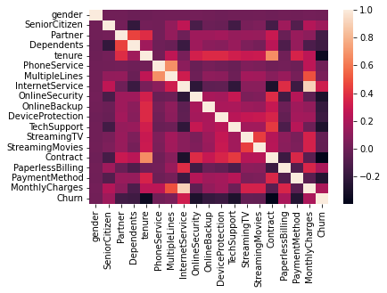

```python
import seaborn as sns

sns.heatmap(t_merg.corr(),annot=False)
```

```python
t_merg.head()
```

|  | customerID | gender | SeniorCitizen | Partner | Dependents | tenure | PhoneService | MultipleLines | InternetService | OnlineSecurity | ... | DeviceProtection | TechSupport | StreamingTV | StreamingMovies | Contract | PaperlessBilling | PaymentMethod | MonthlyCharges | TotalCharges | Churn |
| --- | --- | --- | --- | --- | --- | --- | --- | --- | --- | --- | --- | --- | --- | --- | --- | --- | --- | --- | --- | --- | --- |
| 0 | 7590-VHVEG | 1 | 0.0 | 1 | 0 | 1.0 | 0 | 0 | 1 | 0 | ... | 0 | 0 | 0 | 0 | 0 | 1 | 1 | 29.85 | 29.85 | 0 |
| 1 | 5575-GNVDE | 0 | 0.0 | 0 | 0 | 34.0 | 1 | 1 | 1 | 2 | ... | 2 | 0 | 0 | 0 | 1 | 0 | 2 | 56.95 | 1889.5 | 0 |
| 2 | 3668-QPYBK | 0 | 0.0 | 0 | 0 | 2.0 | 1 | 1 | 1 | 2 | ... | 0 | 0 | 0 | 0 | 0 | 1 | 2 | 53.85 | 108.15 | 1 |
| 3 | 7795-CFOCW | 0 | 0.0 | 0 | 0 | 45.0 | 0 | 0 | 1 | 2 | ... | 2 | 2 | 0 | 0 | 1 | 0 | 3 | 42.30 | 1840.75 | 0 |
| 4 | 9237-HQITU | 1 | 0.0 | 0 | 0 | 2.0 | 1 | 1 | 2 | 0 | ... | 0 | 0 | 0 | 0 | 0 | 1 | 1 | 70.70 | 151.65 | 1 |

5 rows × 21 columns

```python
t_merg.drop(['gender','PhoneService', 'tenure','TotalCharges'],inplace = True, axis =1)
```

```python
t_merg.head()
```

|  | customerID | SeniorCitizen | Partner | Dependents | MultipleLines | InternetService | OnlineSecurity | OnlineBackup | DeviceProtection | TechSupport | StreamingTV | StreamingMovies | Contract | PaperlessBilling | PaymentMethod | MonthlyCharges | Churn |
| --- | --- | --- | --- | --- | --- | --- | --- | --- | --- | --- | --- | --- | --- | --- | --- | --- | --- |
| 0 | 7590-VHVEG | 0.0 | 1 | 0 | 0 | 1 | 0 | 2 | 0 | 0 | 0 | 0 | 0 | 1 | 1 | 29.85 | 0 |
| 1 | 5575-GNVDE | 0.0 | 0 | 0 | 1 | 1 | 2 | 0 | 2 | 0 | 0 | 0 | 1 | 0 | 2 | 56.95 | 0 |
| 2 | 3668-QPYBK | 0.0 | 0 | 0 | 1 | 1 | 2 | 2 | 0 | 0 | 0 | 0 | 0 | 1 | 2 | 53.85 | 1 |
| 3 | 7795-CFOCW | 0.0 | 0 | 0 | 0 | 1 | 2 | 0 | 2 | 2 | 0 | 0 | 1 | 0 | 3 | 42.30 | 0 |
| 4 | 9237-HQITU | 0.0 | 0 | 0 | 1 | 2 | 0 | 0 | 0 | 0 | 0 | 0 | 0 | 1 | 1 | 70.70 | 1 |

```python
t_merg1 = t_merg.drop(labels = "customerID", axis = 1) #this column has nothing to do with the churn or donot churn so drop this colum as well
```

```python
t_merg1.head()
```

|  | SeniorCitizen | Partner | Dependents | MultipleLines | InternetService | OnlineSecurity | OnlineBackup | DeviceProtection | TechSupport | StreamingTV | StreamingMovies | Contract | PaperlessBilling | PaymentMethod | MonthlyCharges | Churn |
| --- | --- | --- | --- | --- | --- | --- | --- | --- | --- | --- | --- | --- | --- | --- | --- | --- |
| 0 | 0.0 | 1 | 0 | 0 | 1 | 0 | 2 | 0 | 0 | 0 | 0 | 0 | 1 | 1 | 29.85 | 0 |
| 1 | 0.0 | 0 | 0 | 1 | 1 | 2 | 0 | 2 | 0 | 0 | 0 | 1 | 0 | 2 | 56.95 | 0 |
| 2 | 0.0 | 0 | 0 | 1 | 1 | 2 | 2 | 0 | 0 | 0 | 0 | 0 | 1 | 2 | 53.85 | 1 |
| 3 | 0.0 | 0 | 0 | 0 | 1 | 2 | 0 | 2 | 2 | 0 | 0 | 1 | 0 | 3 | 42.30 | 0 |
| 4 | 0.0 | 0 | 0 | 1 | 2 | 0 | 0 | 0 | 0 | 0 | 0 | 0 | 1 | 1 | 70.70 | 1 |

```python
X = t_merg1.drop(labels= 'Churn' , axis = 1)
y = t_merg1["Churn"]
X.head()
```

|  | SeniorCitizen | Partner | Dependents | MultipleLines | InternetService | OnlineSecurity | OnlineBackup | DeviceProtection | TechSupport | StreamingTV | StreamingMovies | Contract | PaperlessBilling | PaymentMethod | MonthlyCharges |
| --- | --- | --- | --- | --- | --- | --- | --- | --- | --- | --- | --- | --- | --- | --- | --- |
| 0 | 0.0 | 1 | 0 | 0 | 1 | 0 | 2 | 0 | 0 | 0 | 0 | 0 | 1 | 1 | 29.85 |
| 1 | 0.0 | 0 | 0 | 1 | 1 | 2 | 0 | 2 | 0 | 0 | 0 | 1 | 0 | 2 | 56.95 |
| 2 | 0.0 | 0 | 0 | 1 | 1 | 2 | 2 | 0 | 0 | 0 | 0 | 0 | 1 | 2 | 53.85 |
| 3 | 0.0 | 0 | 0 | 0 | 1 | 2 | 0 | 2 | 2 | 0 | 0 | 1 | 0 | 3 | 42.30 |
| 4 | 0.0 | 0 | 0 | 1 | 2 | 0 | 0 | 0 | 0 | 0 | 0 | 0 | 1 | 1 | 70.70 |

```python
# convert the features into z scores as we do not know what units / scales were used and store them in new dataframe
# It is always adviced to scale numeric attributes in models that calculate distances.

XScaled  = X.apply(zscore)  # convert all attributes to Z scale

XScaled.describe()
```

|  | SeniorCitizen | Partner | Dependents | MultipleLines | InternetService | OnlineSecurity | OnlineBackup | DeviceProtection | TechSupport | StreamingTV | StreamingMovies | Contract | PaperlessBilling | PaymentMethod | MonthlyCharges |
| --- | --- | --- | --- | --- | --- | --- | --- | --- | --- | --- | --- | --- | --- | --- | --- |
| count | 7.043000e+03 | 7.043000e+03 | 7.043000e+03 | 7.043000e+03 | 7.043000e+03 | 7.043000e+03 | 7.043000e+03 | 7.043000e+03 | 7.043000e+03 | 7.043000e+03 | 7.043000e+03 | 7.043000e+03 | 7.043000e+03 | 7.043000e+03 | 7.043000e+03 |
| mean | -4.842546e-17 | 7.162933e-17 | 1.069396e-16 | 1.402321e-16 | -5.145205e-17 | 6.809830e-17 | 2.295165e-17 | -4.539887e-17 | -3.127478e-17 | 2.169057e-17 | 7.062046e-18 | -7.566478e-17 | -5.952296e-17 | -1.916841e-17 | -6.406285e-17 |
| std | 1.000071e+00 | 1.000071e+00 | 1.000071e+00 | 1.000071e+00 | 1.000071e+00 | 1.000071e+00 | 1.000071e+00 | 1.000071e+00 | 1.000071e+00 | 1.000071e+00 | 1.000071e+00 | 1.000071e+00 | 1.000071e+00 | 1.000071e+00 | 1.000071e+00 |
| min | -4.399165e-01 | -9.666223e-01 | -6.540119e-01 | -2.061669e+00 | -1.570214e+00 | -9.188378e-01 | -1.029919e+00 | -1.027910e+00 | -9.252621e-01 | -1.113495e+00 | -1.121405e+00 | -8.282069e-01 | -1.205113e+00 | -1.145198e+00 | -1.545860e+00 |
| 25% | -4.399165e-01 | -9.666223e-01 | -6.540119e-01 | -5.056967e-01 | -2.862227e-01 | -9.188378e-01 | -1.029919e+00 | -1.027910e+00 | -9.252621e-01 | -1.113495e+00 | -1.121405e+00 | -8.282069e-01 | -1.205113e+00 | -1.145198e+00 | -9.725399e-01 |
| 50% | -4.399165e-01 | -9.666223e-01 | -6.540119e-01 | -5.056967e-01 | -2.862227e-01 | 2.442417e-01 | 1.063153e-01 | 1.086002e-01 | 2.355183e-01 | 1.652594e-02 | 8.502786e-03 | -8.282069e-01 | 8.297975e-01 | -2.747437e-01 | 1.857327e-01 |
| 75% | -4.399165e-01 | 1.034530e+00 | 1.529024e+00 | 1.050276e+00 | 9.977688e-01 | 1.407321e+00 | 1.242550e+00 | 1.245111e+00 | 1.396299e+00 | 1.146547e+00 | 1.138411e+00 | 3.712710e-01 | 8.297975e-01 | 5.957106e-01 | 8.338335e-01 |
| max | 2.273159e+00 | 1.034530e+00 | 1.529024e+00 | 1.050276e+00 | 9.977688e-01 | 1.407321e+00 | 1.242550e+00 | 1.245111e+00 | 1.396299e+00 | 1.146547e+00 | 1.138411e+00 | 1.570749e+00 | 8.297975e-01 | 1.466165e+00 | 1.794352e+00 |

```python
XScaled.shape
```

```
(7043, 15)
```

```python
# Split X and y into training and test set in 80:20 ratio

X_train, X_test, y_train, y_test = train_test_split(XScaled, y, test_size=0.20, random_state=1)
```

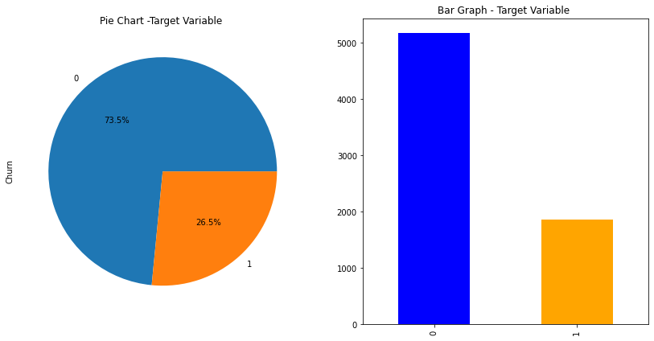

```python
fig,axes=plt.subplots(1,2,figsize=(14,7))
t_merg1['Churn'].value_counts().plot.pie(autopct='%1.1f%%',ax=axes[0])
t_merg1.Churn.value_counts().plot(color = ['blue','orange'],kind='bar',ax=axes[1])
axes[0].set_title('Pie Chart -Target Variable ')
axes[1].set_title('Bar Graph - Target Variable ')
plt.show()
```

```python
y_train.to_frame().value_counts(normalize=True)
```

```
Churn
0        0.730032
1        0.269968
dtype: float64
```

```python
y_test.to_frame().value_counts(normalize=True)
```

```
Churn
0        0.753016
1        0.246984
dtype: float64
```

```python
from imblearn.over_sampling import RandomOverSampler# oversampling
# define oversampling strategy
oversample = RandomOverSampler(sampling_strategy='minority')
# fit and apply the transform
X_over, y_over = oversample.fit_resample(X_train, y_train)
print("Number of records oversample Data X: ", X_over.shape)
print("Number of records oversample Data y: ", y_over.shape)
print("Number of records split train Data X: ", X_train.shape)
print("Number of records split train Data y: ", y_train.shape)
```

```
Number of records oversample Data X:  (8226, 15)
Number of records oversample Data y:  (8226,)
Number of records split train Data X:  (5634, 15)
Number of records split train Data y:  (5634,)
```

```python
y_over.to_frame().value_counts(normalize=True)
```

```
Churn
0        0.5
1        0.5
dtype: float64
```

3. Model building and Improvement: [10 Marks] A. Train a model using XGBoost. Also print best performing parameters along with train and test performance. [5 Marks] B. Improve performance of the XGBoost as much as possible. Also print best performing parameters along with train and test performance. [5 Marks

```python
from sklearn.metrics import confusion_matrix, accuracy_score, classification_report
import time

def evaluate(model, X_train, X_test, y_train, y_test, duration):
    y_test_pred = model.predict(X_test)
    y_train_pred = model.predict(X_train)

    print('{}'.format('\033[1m'))
    print("TRAINIG RESULTS: \n===============================")
    clf_report = pd.DataFrame(classification_report(y_train, y_train_pred, output_dict=True))
    print(f"CONFUSION MATRIX:\n{confusion_matrix(y_train, y_train_pred)}")
    print(f"ACCURACY SCORE:\n{accuracy_score(y_train, y_train_pred):.4f}")
    print(f"CLASSIFICATION REPORT:\n{clf_report}")
    print("\n")

    print("TESTING RESULTS: \n===============================")
    clf_report = pd.DataFrame(classification_report(y_test, y_test_pred, output_dict=True))
    print(f"CONFUSION MATRIX:\n{confusion_matrix(y_test, y_test_pred)}")
    print(f"ACCURACY SCORE:\n{accuracy_score(y_test, y_test_pred):.4f}")
    print(f"CLASSIFICATION REPORT:\n{clf_report}")
    print("\n")
    print("TIME ELAPSED : ", duration)
```

```python
from xgboost import XGBClassifier

xg_boost_clf = XGBClassifier(n_estimators=100,eval_metric='logloss', random_state=42)
xg_boost_clf.fit(X_train, y_train)

print("MODEL : XGBoost \n")
evaluate(xg_boost_clf, X_train, X_test, y_train, y_test,'duration')
```

```
MODEL : XGBoost


TRAINIG RESULTS:
===============================
CONFUSION MATRIX:
[[3847  266]
 [ 375 1146]]
ACCURACY SCORE:
0.8862
CLASSIFICATION REPORT:
                     0            1  accuracy    macro avg  weighted avg
precision     0.911180     0.811615  0.886226     0.861397      0.884300
recall        0.935327     0.753452  0.886226     0.844389      0.886226
f1-score      0.923095     0.781452  0.886226     0.852274      0.884856
support    4113.000000  1521.000000  0.886226  5634.000000   5634.000000


TESTING RESULTS:
===============================
CONFUSION MATRIX:
[[913 148]
 [162 186]]
ACCURACY SCORE:
0.7800
CLASSIFICATION REPORT:
                     0           1  accuracy    macro avg  weighted avg
precision     0.849302    0.556886  0.779986     0.703094      0.777080
recall        0.860509    0.534483  0.779986     0.697496      0.779986
f1-score      0.854869    0.545455  0.779986     0.700162      0.778449
support    1061.000000  348.000000  0.779986  1409.000000   1409.000000


TIME ELAPSED :  duration
```

```python
from datetime import datetime
from sklearn.model_selection import RandomizedSearchCV, GridSearchCV
from sklearn.metrics import roc_auc_score
from sklearn.model_selection import StratifiedKFold
from xgboost import XGBClassifier
```

```python
params = {
        'min_child_weight': [1, 5, 10],
        'gamma': [0.5, 1, 1.5, 2, 5],
        'subsample': [0.6, 0.8, 1.0],
        'colsample_bytree': [0.6, 0.8, 1.0],
        'max_depth': [1, 2, 3,4, 5, 6, 7, 8, 9, 10, 20, 25, 30]
        }
```

```python
def timer(start_time=None):
    if not start_time:
        start_time = datetime.now()
        return start_time
    elif start_time:
        thour, temp_sec = divmod((datetime.now() - start_time).total_seconds(), 3600)
        tmin, tsec = divmod(temp_sec, 60)
        print('\n Time taken: %i hours %i minutes and %s seconds.' % (thour, tmin, round(tsec, 2)))
```

```python
xgb = XGBClassifier(learning_rate=0.02, n_estimators=600, objective='binary:logistic',
                    silent=True, nthread=1)
```

```python
folds = 5
param_comb = 5

skf = StratifiedKFold(n_splits=folds, shuffle = True, random_state = 1001)

random_search = RandomizedSearchCV(xgb, param_distributions=params, n_iter=param_comb, scoring='roc_auc', n_jobs=4, cv=skf.split(X,y), verbose=3, random_state=1001 )

# Here we go
start_time = timer(None) # timing starts from this point for "start_time" variable
random_search.fit(X, y)
timer(start_time) # timing ends here for "start_time" variable
```

```
Fitting 5 folds for each of 5 candidates, totalling 25 fits
[18:58:24] WARNING: C:/Users/administrator/workspace/xgboost-win64_release_1.6.0/src/learner.cc:627:
Parameters: { "silent" } might not be used.

  This could be a false alarm, with some parameters getting used by language bindings but
  then being mistakenly passed down to XGBoost core, or some parameter actually being used
  but getting flagged wrongly here. Please open an issue if you find any such cases.



 Time taken: 0 hours 0 minutes and 34.84 seconds.
```

```python
print('\n All results:')
print(random_search.cv_results_)
print('\n Best estimator:')
print(random_search.best_estimator_)
print('\n Best normalized gini score for %d-fold search with %d parameter combinations:' % (folds, param_comb))
print(random_search.best_score_ * 2 - 1)
print('\n Best hyperparameters:') # for printing the best hyperparameter by grid search
print(random_search.best_params_)
results = pd.DataFrame(random_search.cv_results_)
results.to_csv('xgb-random-grid-search-results-01.csv', index=False)
```

[output not shown]

```python
xg_boost_clf = XGBClassifier(n_estimators=600,subsample= 1.0, gamma= 2, eval_metric='logloss', random_state=0, best_score=0.5, booster= 'gbtree', colsample_bytree= 1.0)
xg_boost_clf.fit(X_train, y_train)

print("MODEL : XGBoost \n")
evaluate(xg_boost_clf, X_train, X_over, y_train, y_over,'duration')
```

```
[18:58:27] WARNING: C:/Users/administrator/workspace/xgboost-win64_release_1.6.0/src/learner.cc:627:
Parameters: { "best_score" } might not be used.

  This could be a false alarm, with some parameters getting used by language bindings but
  then being mistakenly passed down to XGBoost core, or some parameter actually being used
  but getting flagged wrongly here. Please open an issue if you find any such cases.


MODEL : XGBoost


TRAINIG RESULTS:
===============================
CONFUSION MATRIX:
[[3751  362]
 [ 664  857]]
ACCURACY SCORE:
0.8179
CLASSIFICATION REPORT:
                     0            1  accuracy    macro avg  weighted avg
precision     0.849604     0.703035  0.817891     0.776319      0.810035
recall        0.911986     0.563445  0.817891     0.737716      0.817891
f1-score      0.879690     0.625547  0.817891     0.752619      0.811080
support    4113.000000  1521.000000  0.817891  5634.000000   5634.000000


TESTING RESULTS:
===============================
CONFUSION MATRIX:
[[3751  362]
 [1794 2319]]
ACCURACY SCORE:
0.7379
CLASSIFICATION REPORT:
                     0            1  accuracy    macro avg  weighted avg
precision     0.676465     0.864976  0.737904     0.770721      0.770721
recall        0.911986     0.563822  0.737904     0.737904      0.737904
f1-score      0.776765     0.682661  0.737904     0.729713      0.729713
support    4113.000000  4113.000000  0.737904  8226.000000   8226.000000


TIME ELAPSED :  duration
```

# Question no. 2, Machine work flow

```python
# Importing the required packages
import pandas as pd
import numpy as np
from sklearn.preprocessing import OneHotEncoder,LabelEncoder
import seaborn as sns
import matplotlib.pyplot as plt
from statsmodels.stats.outliers_influence import variance_inflation_factor as vif
from scipy.stats import zscore
from sklearn.model_selection  import train_test_split
from sklearn.linear_model import LinearRegression
from sklearn.linear_model import LogisticRegression
from sklearn.neighbors import KNeighborsClassifier
from sklearn.naive_bayes import GaussianNB
from sklearn.svm import SVC
from sklearn import svm
from sklearn.linear_model import Ridge
from sklearn.linear_model import Lasso
from sklearn.ensemble import RandomForestClassifier
from sklearn.metrics import accuracy_score
from sklearn.metrics import precision_score
from sklearn.metrics import recall_score
from sklearn.metrics import f1_score
from sklearn.metrics import r2_score
from sklearn.metrics import mean_absolute_error
from sklearn.metrics import mean_squared_error
import pickle as pk

def seg_iv_dv(tel_df, tf_v):
    #Segregate Dependent and Independet Features
    iv=tel_df.drop(tf_v,axis=1)
    tf=pd.DataFrame(tel_df[[tf_v]])
    return iv,tf

def seg_cat_num(iv):
    #Segregate Catagorical and Numerical Features
    catv=iv.drop(['SeniorCitizen','tenure','MonthlyCharges'],axis=1)
    numv=pd.DataFrame(iv[['SeniorCitizen','tenure','MonthlyCharges']])
    return catv,numv

def merge_df(a,b):
    #Merge DataFrame
    c= pd.merge(a,b,left_index=True, right_index=True)
    return c

#Imputing missing values
def imputmissing(numv, tel_df):
    #Impute missing Values
    percent_missing= numv.isnull().sum()*100/len(tel_df) # check for the missing value in dataframe
    for col in numv.columns:
        a = numv.loc[:,col].isnull().sum()/len(numv)*100
        if(a > 0):
            numv[col].fillna(numv.loc[:,col].median(), inplace = True)
        else:
            print("No missing value/NULL value existed")
    return numv

# Impute duplicate values (you can drop duplicate values)
def removedup(tel_df):
    #Remove Duplicate
    dupes = tel_df.duplicated()
    z=sum(dupes)
    if (z>0):
        tel_df =tel_df.drop_duplicates()
    return tel_df

#Function importing Dataset
def importdata(path_to_csv1 , path_to_csv2):
    #Import CSV
    tel_df1 = pd.read_csv(path_to_csv1)
    tel_df2 = pd.read_csv(path_to_csv2)
    tel_df=tel_df1.merge(tel_df2, on = 'customerID')
    return tel_df

def levelEncoder(tf,tf_v):
    labelencoder = LabelEncoder()
    tf[tf_v] = labelencoder.fit_transform(tf[tf_v])
    return tf

#Encode the variables
def oneHotEncoder(iv):
    #One Hot Encode the data
    iv_en= pd.get_dummies(iv, columns=['gender','Partner','Dependents','PhoneService','MultipleLines','InternetService','OnlineSecurity','OnlineBackup','DeviceProtection','TechSupport','StreamingTV','StreamingMovies','Contract','PaperlessBilling','PaymentMethod'])
    return iv_en

# Drop the features using VIF factor
def vif_drop_feature(iv_en):
    #drop the dependent featires using VIF
    cols = iv_en.columns
    cols = cols.delete(0)
    X23 = iv_en[cols]
    for i in range(len(cols)):
        f_li = [vif(iv_en[cols].values, index) for index in range(len(cols))]
        m_vif = max(f_li)
        di = f_li.index(m_vif)
        if m_vif > 5:
            cols = cols.delete(di)
    iv_en = iv_en[cols]
    return iv_en

#Drop Features
def drop_feature_df(iv_en):
    #drop the uncessary features
    iv_en=iv_en.drop(['customerID','TotalCharges'],axis=1)
    return iv_en

#Convert data types int to float
def int_to_float(iv_en):
    #Change the datatypes from int to float
    iv_en = iv_en.astype(float)
    return iv_en

# Function to preprocess the data
def preprocess_data(path_to_csv1 , path_to_csv2 , tf_v):
    tel_df = importdata(path_to_csv1 , path_to_csv2)
    iv , tf = seg_iv_dv(tel_df , tf_v)
    catv, numv = seg_cat_num(iv)
    numv = imputmissing(numv, tel_df)
    iv = merge_df(catv , numv)
    tel_def = removedup(tel_df)
    tf = levelEncoder(tf,tf_v)
    iv_en = oneHotEncoder(iv)
    iv_en = drop_feature_df(iv_en)
    iv_en = int_to_float(iv_en)
    iv_en = vif_drop_feature(iv_en)
    tel_df = merge_df(iv_en , tf)
    tel_df = tel_df.astype(float)
    return tel_df, tf

def zScore(tel_df):
    scaled_tel_df = tel_df.apply(zscore)
    return scaled_tel_df

# Function to split the dataset
def splitdataset(tel_df , tf_v):
    # Separating the target variable
    X, y=seg_iv_dv(tel_df , tf_v)
    # Splitting the dataset into train and test
    X_train, X_test, y_train, y_test = train_test_split(X, y, test_size = 0.3, random_state = 100)
    return X_train, X_test, y_train, y_test

#Build multiple models.
def train_modals(X_train, y_train):

    lr = LinearRegression()
    lr.fit(X_train, y_train)
    ridge = Ridge()
    ridge.fit(X_train, y_train)
    modell = LogisticRegression(solver="liblinear")
    modell.fit(X_train, y_train)
    modelg = GaussianNB()
    modelg.fit(X_train, y_train)
    knn = KNeighborsClassifier(n_neighbors= 5 )
    knn.fit(X_train, y_train)
    clf = svm.SVC()
    clf.fit(X_train, y_train)
    rfc = RandomForestClassifier()
    rfc.fit(X_train, y_train)
    return lr,ridge,modell,modelg,knn,clf,rfc

def performance_train_test_score(X_train, y_train, X_test, y_test, lr,ridge,modell,modelg,knn,clf,rfc):

    lr_train = lr.score(X_train, y_train)
    lr_test = lr.score(X_test, y_test)
    print("Linear Regression Train Score: ",lr_train)
    print("Linear Regression Test Score: ",lr_test)

    ridge_train = ridge.score(X_train, y_train)
    ridge_test = ridge.score(X_test, y_test)
    print("Ridge Train Score: ",ridge_train)
    print("Ridge Test Score: ",ridge_test)


    modell_train = modell.score(X_train, y_train)
    modell_test = modell.score(X_test, y_test)
    print("Logistic Regression Train Score: ",modell_train)
    print("Logistic Regression Test Score: ",modell_test)

    modelg_train = modelg.score(X_train, y_train)
    modelg_test = modelg.score(X_test, y_test)
    print("Gaussian Train Score: ",modelg_train)
    print("Gaussian Test Score: ",modelg_test)
```

```python
    knn_train = knn.score(X_train, y_train)
    knn_test = knn.score(X_test, y_test)
    print("K Neighbours Classifier Train Score: ",knn_train)
    print("K Neighbours Classifier Test Score: ",knn_test)

    clf_train = clf.score(X_train, y_train)
    clf_test = clf.score(X_test, y_test)
    print("Support Vector Machine Train Score: ",clf_train)
    print("Support Vector Machine Test Score: ",clf_test)

    rfc_train = rfc.score(X_train, y_train)
    rfc_test = rfc.score(X_test, y_test)
    print("Random Forest Classification Train Score: ",rfc_train)
    print("Random Forest Classification Test Score: ",rfc_test)

# Function to make predictions
def prediction(X_train, X_test, lr,ridge,modell,modelg,knn,clf,rfc):
    y_pred_lr_n = lr.predict(X_train)
    y_pred_lr_t = lr.predict(X_test)
    y_pred_ridge_n = ridge.predict(X_train)
    y_pred_ridge_t = ridge.predict(X_test)
    y_pred_modell_n = modell.predict(X_train)
    y_pred_modell_t = modell.predict(X_test)
    y_pred_modelg_n = modelg.predict(X_train)
    y_pred_modelg_t = modelg.predict(X_test)
    y_pred_knn_n = knn.predict(X_train)
    y_pred_knn_t = knn.predict(X_test)
    y_pred_clf_n = clf.predict(X_train)
    y_pred_clf_t = clf.predict(X_test)
    y_pred_rfc_n = rfc.predict(X_train)
    y_pred_rfc_t = rfc.predict(X_test)

    return y_pred_lr_n,y_pred_lr_t,y_pred_ridge_n,y_pred_ridge_t,y_pred_modell_n,y_pred_modell_t,y_pred_modelg_n,y_pred_modelg_t,y_pred_knn_n,y_pred_knn_t,y_pred_clf_n,y_pred_clf_t,y_pred_rfc_n,y_pred_rfc_t

# Function to calculate accuracy
def performance_matrics(y_train, y_test, y_pred_lr_n,y_pred_lr_t,y_pred_ridge_n,y_pred_ridge_t,y_pred_modell_n,y_pred_modell_t,y_pred_modelg_n,y_pred_modelg_t,y_pred_knn_n,y_pred_knn_t,y_pred_clf_n,y_pred_clf_t,y_pred_rfc_n,y_pred_rfc_t,lr,ridge,modell,modelg,knn,clf,rfc):

    #Linear Regression

    lr_train_r2=r2_score(y_train,y_pred_lr_n)*100
    lr_test_r2=r2_score(y_test,y_pred_lr_t)*100
    lr_train_mse=mean_squared_error(y_train,y_pred_lr_n)
    lr_test_mse=mean_squared_error(y_test,y_pred_lr_t)

    lr_results_df = pd.DataFrame([lr,lr_train_r2, lr_test_r2, lr_train_mse,lr_test_mse]).transpose()
    lr_results_df.columns = ['Method','Training R2/Train Accuracy','Test R2/Test Accuracy','Training MSE','Test MSE']

    #RIDGE

    r_train_r2=r2_score(y_train,y_pred_ridge_n)*100
    r_test_r2=r2_score(y_test,y_pred_ridge_t)*100
    r_train_mse=mean_absolute_error(y_train,y_pred_ridge_n)
    r_test_mse=mean_squared_error(y_test,y_pred_ridge_t)
    r_results_df = pd.DataFrame([ridge, r_train_r2, r_test_r2, r_train_mse,r_test_mse]).transpose()
    r_results_df.columns = ['Method','Training R2/Train Accuracy','Test R2/Test Accuracy','Training MSE','Test MSE']

    #Logistic Regression

    l_train_acc=accuracy_score(y_train,y_pred_modell_n)*100
    l_test_acc=accuracy_score(y_test,y_pred_modell_t)*100
    l_train_pre=precision_score(y_train, y_pred_modell_n)
    l_test_pre=precision_score(y_test, y_pred_modell_t)
    l_train_re=recall_score(y_train, y_pred_modell_n)
    l_test_re=recall_score(y_test, y_pred_modell_t)
    l_train_f=f1_score(y_train, y_pred_modell_n)
    l_test_f=f1_score(y_test, y_pred_modell_t)
    l_results_df = pd.DataFrame([modell,l_train_acc,l_test_acc,l_train_pre, l_test_pre,l_train_re,l_test_re,l_train_f,l_test_f,]).transpose()
    l_results_df.columns = ['Method','Training R2/Train Accuracy','Test R2/Test Accuracy','Train Precision','Test Precision','Train Recall','Test Recall','Train F1-Score','Test F1-Score']

    #Gaussian

    g_train_acc=accuracy_score(y_train,y_pred_modelg_n)*100
    g_test_acc=accuracy_score(y_test,y_pred_modelg_t)*100
    g_train_pre=precision_score(y_train, y_pred_modelg_n)
    g_test_pre=precision_score(y_test, y_pred_modelg_t)
    g_train_re=recall_score(y_train, y_pred_modelg_n)
    g_test_re=recall_score(y_test, y_pred_modelg_t)
    g_train_f=f1_score(y_train, y_pred_modelg_n)
    g_test_f=f1_score(y_test, y_pred_modelg_t)
    g_results_df = pd.DataFrame([modelg,g_train_acc,g_test_acc,g_train_pre, g_test_pre,g_train_re,g_test_re,g_train_f,g_test_f,]).transpose()
    g_results_df.columns = ['Method','Training R2/Train Accuracy','Test R2/Test Accuracy','Train Precision','Test Precision','Train Recall','Test Recall','Train F1-Score','Test F1-Score']

    #KNN

    k_train_acc=accuracy_score(y_train,y_pred_knn_n)*100
    k_test_acc=accuracy_score(y_test,y_pred_knn_t)*100
    k_train_pre=precision_score(y_train, y_pred_knn_n)
    k_test_pre=precision_score(y_test, y_pred_knn_t)
    k_train_re=recall_score(y_train, y_pred_knn_n)
    k_test_re=recall_score(y_test, y_pred_knn_t)
    k_train_f=f1_score(y_train, y_pred_knn_n)
    k_test_f=f1_score(y_test, y_pred_knn_t)
    k_results_df = pd.DataFrame([knn, k_train_acc,k_test_acc,k_train_pre, k_test_pre,k_train_re,k_test_re,k_train_f,k_test_f,]).transpose()
    k_results_df.columns = ['Method','Training R2/Train Accuracy','Test R2/Test Accuracy','Train Precision','Test Precision','Train Recall','Test Recall','Train F1-Score','Test F1-Score']

    #Support Vector Machine

    s_train_acc=accuracy_score(y_train,y_pred_clf_n)*100
    s_test_acc=accuracy_score(y_test,y_pred_clf_t)*100
    s_train_pre=precision_score(y_train, y_pred_clf_n)
    s_test_pre=precision_score(y_test, y_pred_clf_t)
    s_train_re=recall_score(y_train, y_pred_clf_n)
    s_test_re=recall_score(y_test, y_pred_clf_t)
    s_train_f=f1_score(y_train, y_pred_clf_n)
    s_test_f=f1_score(y_test, y_pred_clf_t)
    s_results_df = pd.DataFrame([clf, s_train_acc,s_test_acc,s_train_pre, s_test_pre,s_train_re,s_test_re,s_train_f,s_test_f]).transpose()
    s_results_df.columns = ['Method','Training R2/Train Accuracy','Test R2/Test Accuracy','Train Precision','Test Precision','Train Recall','Test Recall','Train F1-Score','Test F1-Score']

    #Random Forest Classifier

    r_train_acc=accuracy_score(y_train,y_pred_rfc_n)*100
    r_test_acc=accuracy_score(y_test,y_pred_rfc_t)*100
    r_train_pre=precision_score(y_train, y_pred_rfc_n)
    r_test_pre=precision_score(y_test, y_pred_rfc_t)
    r_train_re=recall_score(y_train, y_pred_rfc_n)
    r_test_re=recall_score(y_test, y_pred_rfc_t)
    r_train_f=f1_score(y_train, y_pred_rfc_n)
    r_test_f=f1_score(y_test, y_pred_rfc_t)
```

```python
    rf_results_df = pd.DataFrame(['RandomForestClassifier()',r_train_acc,r_test_acc,r_train_pre, r_test_pre,r_train_re,r_test_re,r_train_f,r_test_f]).transpose()
    rf_results_df.columns = ['Method','Training R2/Train Accuracy','Test R2/Test Accuracy','Train Precision','Test Precision','Train Recall','Test Recall','Train F1-Score','Test F1-Score']

    df_results = pd.concat([lr_results_df,r_results_df,l_results_df,g_results_df,k_results_df,s_results_df,rf_results_df])

    return df_results




#Building Modal
def building_modal(tel_df , tf_v):
    iv , tf = seg_iv_dv(tel_df , tf_v)
    scaled_iv = zScore(iv)
    scaled_tel_df = merge_df(scaled_iv , tf)
    X_train, X_test, y_train, y_test = splitdataset(scaled_tel_df, tf_v)
    #Splitted the data in 30% to 70% successfully
    lr,ridge,modell,modelg,knn,clf,rfc = train_modals(X_train, y_train)
    #All models have trained successfully
    #performance_train_test_score(X_train, y_train, X_test, y_test, lr,ridge,lasso,modell,modelg,knn,clf,rfc)
    y_pred_lr_n,y_pred_lr_t,y_pred_ridge_n,y_pred_ridge_t,y_pred_modell_n,y_pred_modell_t,y_pred_modelg_n,y_pred_modelg_t,y_pred_knn_n,y_pred_knn_t,y_pred_clf_n,y_pred_clf_t,y_pred_rfc_n,y_pred_rfc_t = prediction(X_train, X_test, lr,ridge,modell,modelg,knn,clf,rfc)
    #Pridiction successfully
    df_results=performance_matrics(y_train,y_test, y_pred_lr_n,y_pred_lr_t,y_pred_ridge_n,y_pred_ridge_t,y_pred_modell_n,y_pred_modell_t,y_pred_modelg_n,y_pred_modelg_t,y_pred_knn_n,y_pred_knn_t,y_pred_clf_n,y_pred_clf_t,y_pred_rfc_n,y_pred_rfc_t,lr,ridge,modell,modelg,knn,clf,rfc)
    #Performance Matrics generated
    return df_results, X_test, y_test

def main():

    path_to_csv1="C:/Users/dioni/Downloads/Ensemble Techniques/TelcomCustomer-Churn_1.csv"
    path_to_csv2="C:/Users/dioni/Downloads/Ensemble Techniques/TelcomCustomer-Churn_2.csv"
    tf_v = "Churn" # As per problem statement

    #Preprossing Phase
    tel_df , tf = preprocess_data(path_to_csv1 , path_to_csv2 , tf_v)

    # Building Phase
    df_results, X_test, y_test = building_modal(tel_df , tf_v)
    print("Given Dataframe :\n", df_results)


    maxval = df_results['Test R2/Test Accuracy'].max()
    var= df_results['Method'].loc[df_results['Test R2/Test Accuracy'] == maxval].values[0]

    fname = 'finalized_model.sav'
    pk.dump(var, open(fname, 'wb'))

    model_loded = pk.load(open(fname, 'rb'))
    r = model_loded.score(X_test, y_test)
    print(var,' Score : ',r)

# Calling main function
if __name__=="__main__": main()
```

```
No missing value/NULL value existed
No missing value/NULL value existed
No missing value/NULL value existed
```

```
Given Dataframe :
                                    Method Training R2/Train Accuracy  \
0                      LinearRegression()                  28.873144
0                                 Ridge()                  28.873143
0  LogisticRegression(solver='liblinear')                  80.892495
0                            GaussianNB()                  76.206897
0                  KNeighborsClassifier()                  83.509128
0                                   SVC()                  82.373225
0                RandomForestClassifier()                  97.870183

  Test R2/Test Accuracy Training MSE  Test MSE Train Precision Test Precision  \
0             24.940011     0.138303  0.147203             NaN            NaN
0             24.940532      0.30047  0.147202             NaN            NaN
0             79.034548          NaN       NaN         0.66454       0.627329
0             73.308093          NaN       NaN        0.534797       0.501182
0             74.585897          NaN       NaN        0.707627       0.527002
0             78.655939          NaN       NaN        0.713163       0.632184
0             77.425461          NaN       NaN        0.965785       0.601831

  Train Recall Test Recall Train F1-Score Test F1-Score
0          NaN         NaN            NaN           NaN
0          NaN         NaN            NaN           NaN
0     0.559478    0.535336         0.6075      0.577693
0     0.766692    0.749117       0.630085      0.600567
0     0.640829         0.5       0.672573      0.513146
0     0.557176    0.485866       0.625592      0.549451
0     0.953185    0.464664       0.959444      0.524427
LogisticRegression(solver='liblinear')  Score :  0.7903454803596782
```